# Notebook

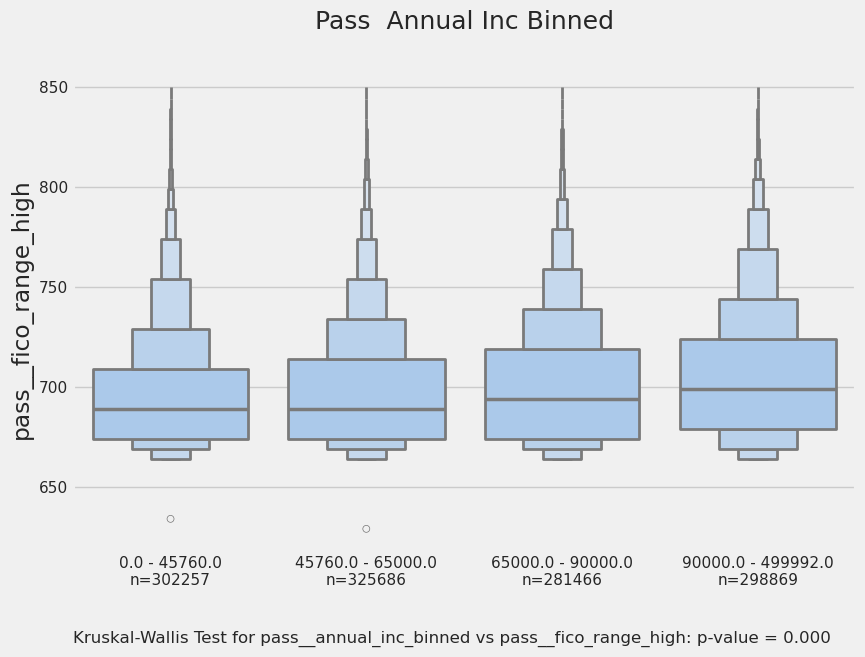

```
None
```

```
'pass__last_fico_range_high_binned vs pass__fico_range_high'
```

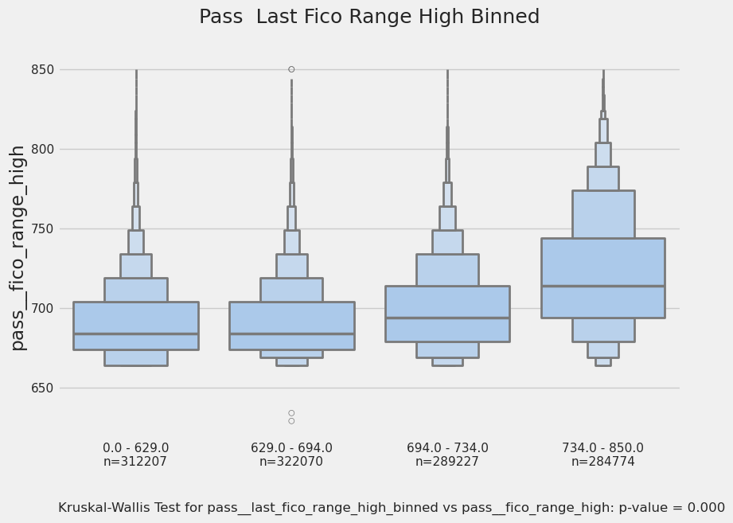

```
None
```

```
'pass__grade vs pass__fico_range_high'
```

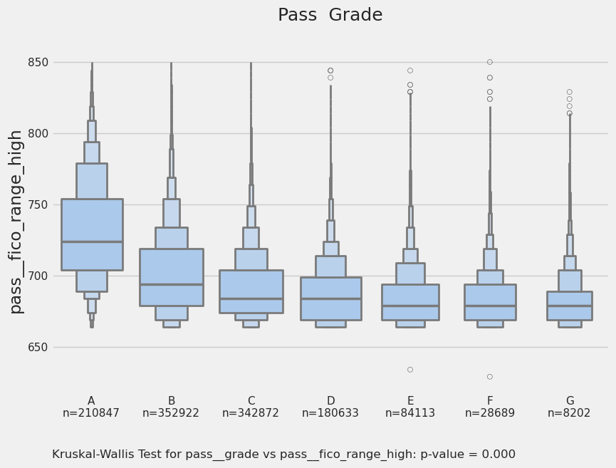

```
None
```

```
'pass__home_ownership vs pass__fico_range_high'
```

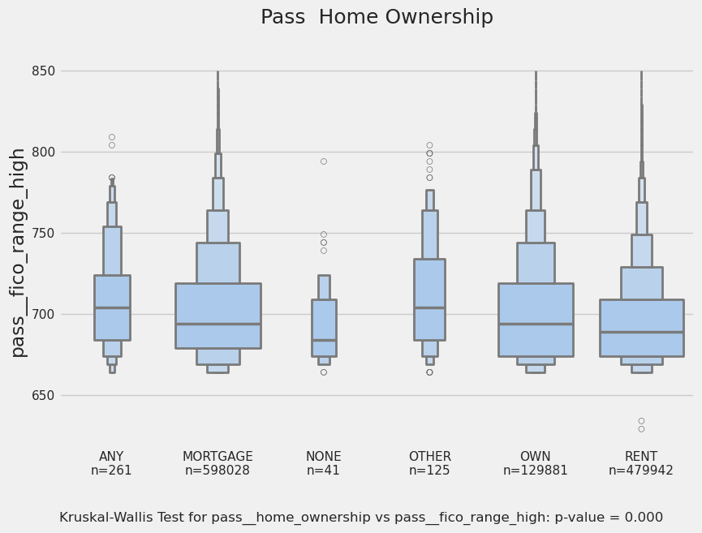

```
None
```

```
'pass__purpose vs pass__fico_range_high'
```

[figure not shown]

```
None
```

[output not shown]

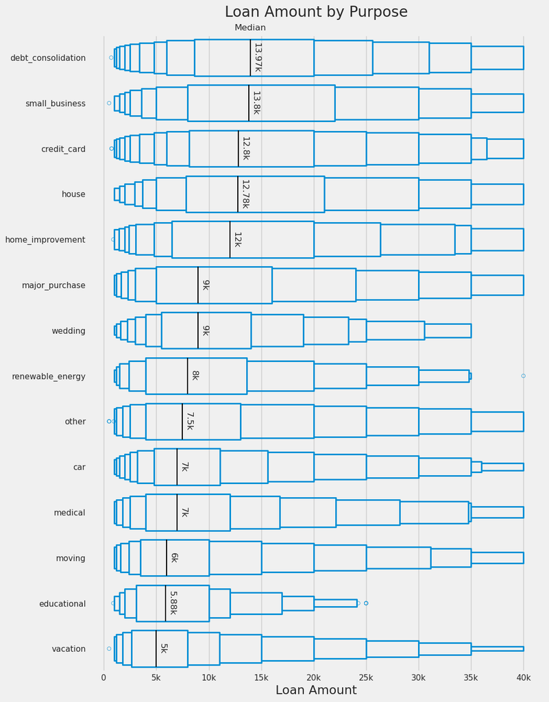

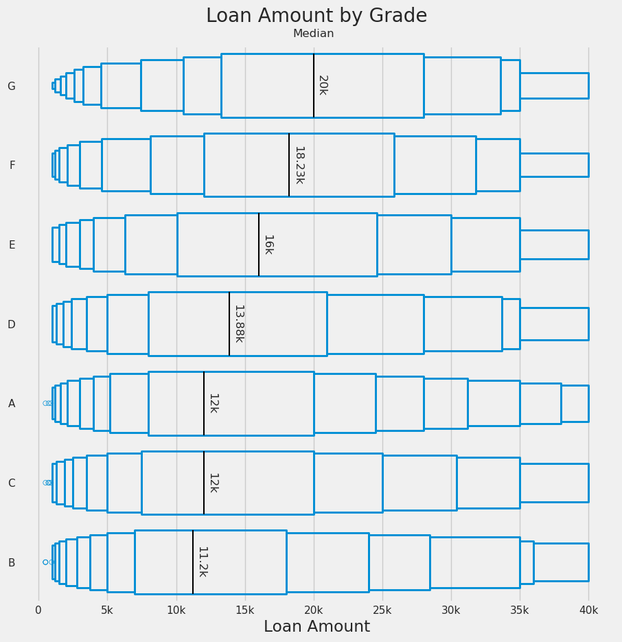

[figure not shown]

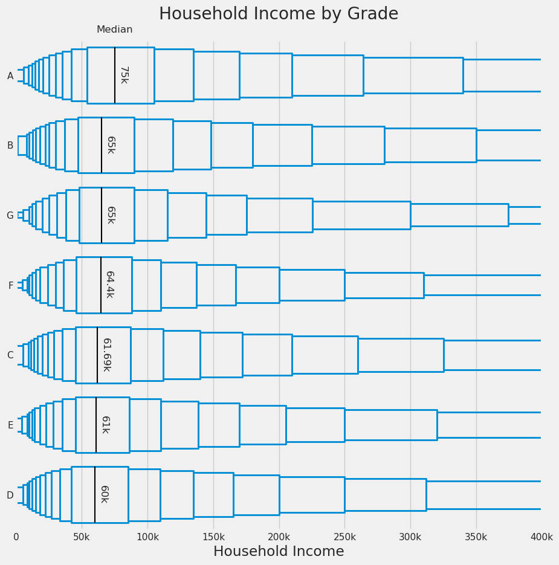

### 1.2.1 Variable Selection

#### 1.2.2 Population Stability Index

We can use PSI to drop unstable features:

Interpreting PSI Values PSI = 0: No change in the distribution between the two datasets. 0 < PSI < 0.1: Indicates a minor change in distribution. Generally acceptable for most applications. 0.1 ≤ PSI < 0.25: Suggests a medium change, warranting investigation. PSI ≥ 0.25: Represents a significant change in the feature distribution, suggesting that the feature's behavior has altered considerably from the baseline. Features with high PSI are often considered unstable and may be dropped from the model to maintain its performance.

```
1210204
```

```
DropHighPSIFeatures(split_frac=0.6)
```

```
{'term_parser__term': 0.0,
 'emp_length_parser__emp_length': 0.0003741361314581748,
 'target__loan_status': 0.0,
 'pass__loan_amnt': 0.003920832633671107,
 'pass__int_rate': 0.0980411585055524,
 'pass__installment': 0.0034312458504524098,
 'pass__annual_inc': 0.0004628902891250139,
 'pass__dti': 0.00860960003097421,
 'pass__delinq_2yrs': 3.3214883865642225e-09,
 'pass__fico_range_low': 0.0001729071232601537,
 'pass__fico_range_high': 0.0001729071232601537,
 'pass__inq_last_6mths': 0.00012248006077575135,
 'pass__open_acc': 0.001492233050605375,
 'pass__pub_rec': 0.0001235793133980767,
 'pass__revol_bal': 0.004023995601426297,
 'pass__revol_util': 0.0015717320542180126,
 'pass__total_acc': 0.001815363644818449,
 'pass__last_fico_range_high': 0.002840491100855753,
 'pass__last_fico_range_low': 0.002840491100855753,
 'pass__collections_12_mths_ex_med': 0.0,
 'pass__inq_fi': 0.0004968674485310809,
 'pass__inq_last_12m': 0.00019709687701067191,
 'pass__chargeoff_within_12_mths': 0.0,
 'pass__mort_acc': 0.000995348626684566,
 'pass__pub_rec_bankruptcies': 3.7430455156439416e-06,
 'pass__tax_liens': 0.0,
 'pass__tot_hi_cred_lim': 0.00011267406754624003,
 'pass__total_bal_ex_mort': 0.000485304089260657}
```